# Создание модели предсказания уровеня удовлетворённости сотрудника

#### Датасет *df_test_features*

```python
df_test_features.head()
```

| id | dept | level | workload | employment_years | last_year_promo | last_year_violations | supervisor_evaluation | salary |
| --- | --- | --- | --- | --- | --- | --- | --- | --- |
| 485046 | marketing | junior | medium | 2 | no | no | 5 | 28800 |
| 686555 | hr | junior | medium | 1 | no | no | 4 | 30000 |
| 467458 | sales | middle | low | 5 | no | no | 4 | 19200 |
| 418655 | sales | middle | low | 6 | no | no | 4 | 19200 |
| 789145 | hr | middle | medium | 5 | no | no | 5 | 40800 |

Рассмотрим признак `dept` датасета *df_test_features*.

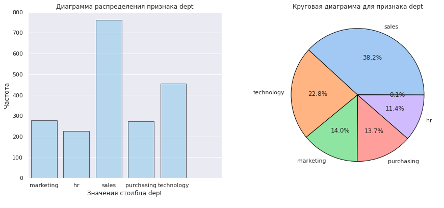

```python
cat_col_graphics(df_test_features, 'dept')
```

Рассмотрим признак `level` датасета *df_test_features*.

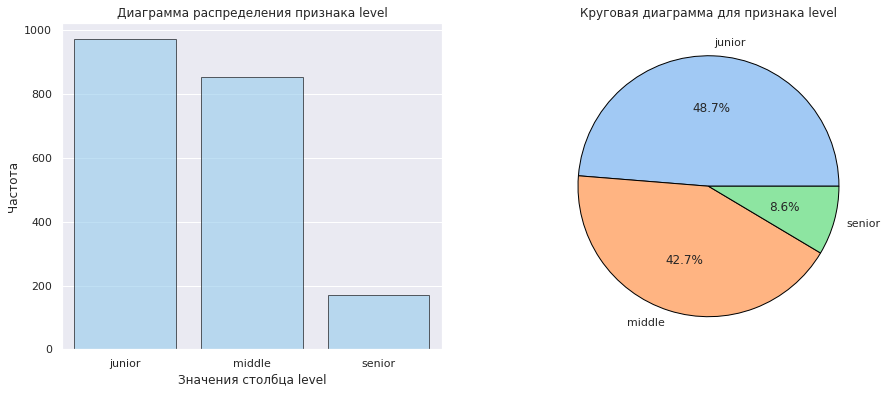

```python
cat_col_graphics(df_test_features, 'level')
```

Рассмотрим признак `workload` датасета *df_test_features*.

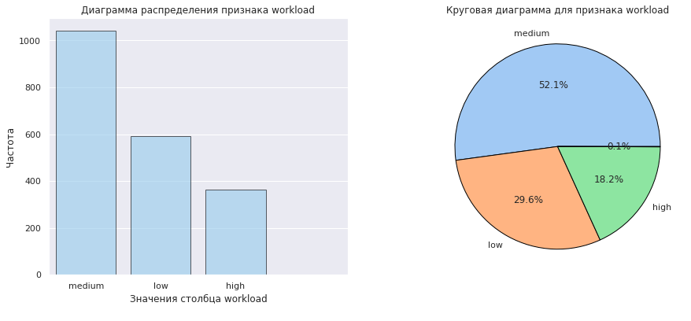

```python
cat_col_graphics(df_test_features, 'workload')
```

Рассмотрим признак `employment_years` датасета *df_test_features*.

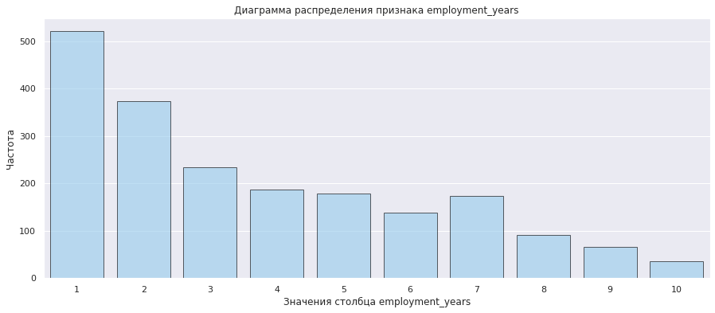

```python
discret_col_graphics(df_test_features, 'employment_years')
```

Рассмотрим признак `last_year_promo` датасета *df_test_features*.

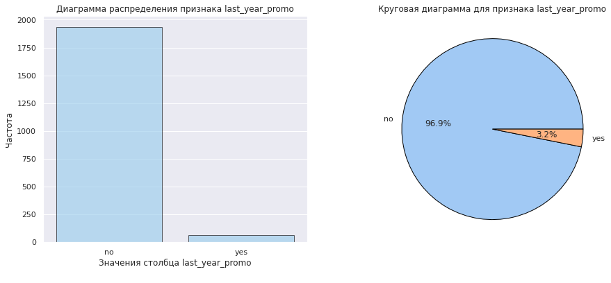

```python
cat_col_graphics(df_test_features, 'last_year_promo')
```

Рассмотрим признак `last_year_violations` датасета *df_test_features*.

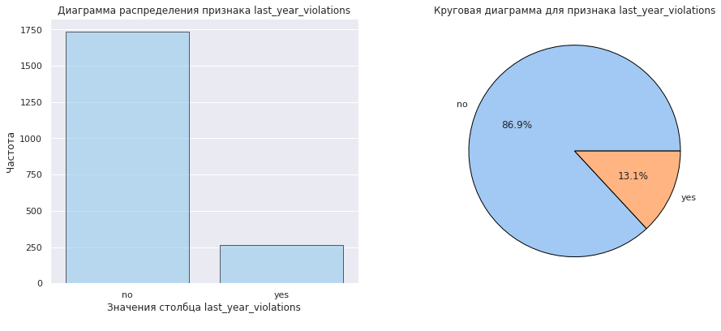

```python
cat_col_graphics(df_test_features, 'last_year_violations')
```

Рассмотрим признак `supervisor_evaluation` датасета *df_test_features*.

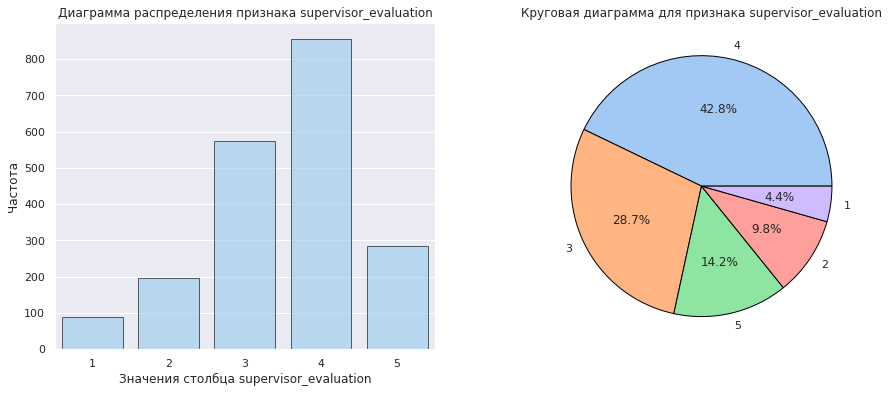

```python
cat_col_graphics(df_test_features, 'supervisor_evaluation')
```

Рассмотрим признак `salary` датасета *df_test_features*.

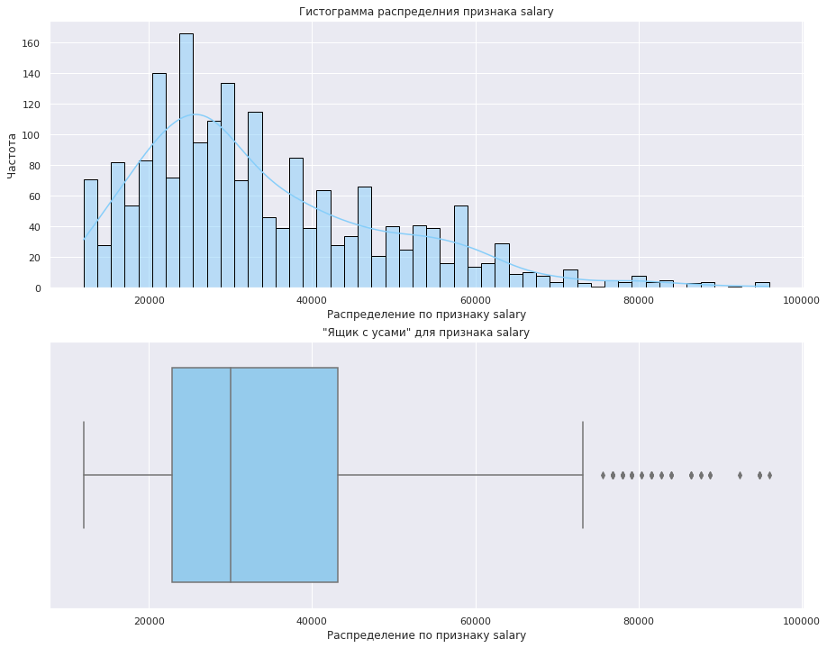

```python
num_col_graphics(df_test_features, 'salary')
```

```python
df_test_features.describe()
```

|  | employment_years | supervisor_evaluation | salary |
| --- | --- | --- | --- |
| count | 2000.000000 | 2000.000000 | 2000.000000 |
| mean | 3.666500 | 3.526500 | 34066.800000 |
| std | 2.537222 | 0.996892 | 15398.436729 |
| min | 1.000000 | 1.000000 | 12000.000000 |
| 25% | 1.000000 | 3.000000 | 22800.000000 |
| 50% | 3.000000 | 4.000000 | 30000.000000 |
| 75% | 6.000000 | 4.000000 | 43200.000000 |
| max | 10.000000 | 5.000000 | 96000.000000 |

Таким образом, в датасете *df_test_features* признаки имеют следующее распределение:

- **dept:** В компании 38,2% людей работают в отделе продаж, 22,8% - в технологическом отделе, 13,7% - в закупках, 14% - в отделе маркетинга и 11,4% - в отделе кадров;
- **level:** 48,7% работников являются младшими сотрудниками, 42,7% сотрудников уровня middle и 8,6% старших сотрудников;
- **workload:** 52,2% сотрудников имеют среднюю нагрузку, 29,7% - низкую и 18,2% - высокую;
- **employment_years:** Средний стаж работы в компании - 3,67 года, при этом максимальное значение - 10 лет. Медиана - 3 года;
- **last_year_promo:** 3,2% сотрудников получили повышение за последний год;
- **last_year_violations:** 13,1 процентов сотрудников нарушали трудовой договор за последний год;
- **supervisor_evaluation:** Среднняя оценка качества работы сотрудника, которую дал руководитель - 3,53 со станд.отклонением - 1,00, медианное значение - 4.
- **salary:** Средняя зарплата в компании - 34066,8 у.ед с большим станд.отклонением в 15398,4 у.ед. Минимальная зарплата - 12000 у.ед, максимальная - 96000 у.ед, медианное значение - 30000 у.ед.